# Analysis of Bike Sharing Rides

## by Osama Adel

## Investigation Overview

In this analysis, the effect of the age, the day of the week and hour of the day on rides' duration is investigated. Also, the effect of the user's type (Customer or Subscribers) and gender on the ride starting hour is also considered.

## Dataset Overview

The data consists of 183412 rides and 16 variables of 4646 bikes over the period of one month (from 1 Feb 2019 to 1 March 2019) from and to 329 stations in San Fransisco Bay area. The variables include the ride start and end times, ride duration, user's type, gender and birth year.

## Distribution of Duration in Seconds

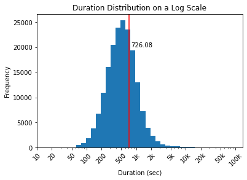

## Distribution of Rides Over Days of Week

The following figure shows the distribution of the rides over the days of week. As shown, the number of rides in Thursday (19% of all rides) is the highest in the week followed by Tuesday (around 17%) then Wedensday (around 16%). Also, it is clear that the number of rides are at minimum in the weekends (Saturday and Sunday at around 8%).

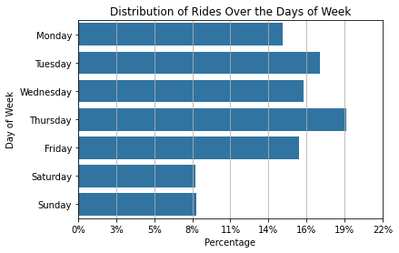

## Birth Year Distribution

The distribution is left skewed which means more of the younger generations from 1980 to 2000 are using the bike sharing service than older generations. It is also clear that some values are anomalies, with birth year before 1920, which means people with ages over 100 years.

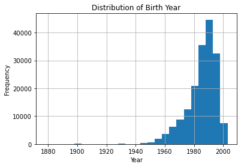

## Ratio of Customers and Subscribers

As shown in the figure, the Subscribers account for more than 87% of all users while Customers are slightly below 11%.

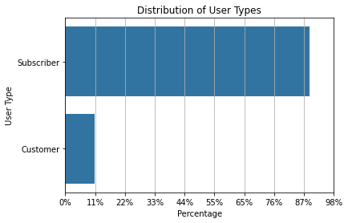

## Distribution of Gender

The figure below shows that about 70% of the users are males while only 22% are females. Around 2-3% of users chose others as their gender.

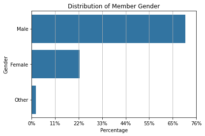

## Effect of Age on Ride Duration

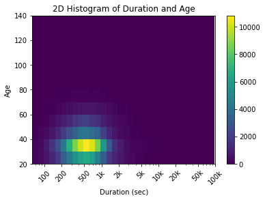

## Effect of Hour of the Day on Ride Duration

As shown in the figure, most of rides take place from 6-10 AM and from 4-8 PM. However, the duration of theses rides have the same distribution from 200-1000 seconds.

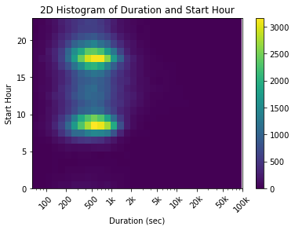

## Starting Hour per Day of Week

It is clear that the distribution of rides over the day changes in the week ends, instead of two peaks from 6-10 AM and 4 to 8 PM, there is a normal distribution of the day with a peak at around 2-3 PM.

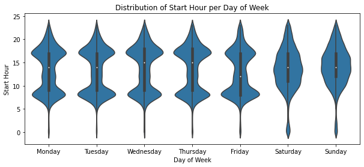

## Effect of User Type on the Duration Over the Week

As shown in the figure, Customers in general take longer rides than Subscribers especially in weekends.

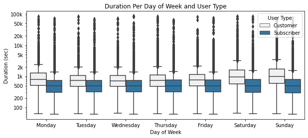